# An R wrapper for scLVM

Florian Buettner, F. Paolo Casale and Oliver Stegle

## Stage 1: Fitting process

As scLVM was originally written in python, we recommend using the native python implementation as demonstrated in the tutorials and ipython notebooks on github. However, we also provide an R wrapper. Note that this is not a native R implementation of scLVM, but calls the relevant python code from within R. That is why, in order to run scLVM-R, you need to install python 2.7 with scipy, h5py, numpy and pylab. It is particularly easy to install python using the anaconda python distribution. scLVM relies heavily on limix, which can be installed using pip install limix on most systems. In addition, you need to install the R package `rPython`. For details on installation and requirements, have a look at the Installation section of our [github page](https://github.com/PMBio/scLVM/wiki/Installation).

In the following we assume you have python, R and all dependencies installed and run the code from the pre-processing notebook. This should provide result in the following variables needed by scLVM:

- Gene x Cell Matrix of normalised and log-transformed read counts: `LogNcountsMmus`
- Boolean vector indicating variable genes (or the gene set for which you would like to run scLVM): `genes_heterogen`
- Technical noise estimates for all genes (in the log space): `LogVar_techMmus`
- Vector of indices of cell cycle genes: `cellcyclegenes_filter`
- Vector of gene IDs: `gene_names`

In order to run scLVM from within R, we first of all need to load the necessary variables into python (using the rPython package).

```r
library(rPython)
```

```r
library(gplots)
#load the wrapper funxtions
source('./R2py.R')

#rename a few variables
load('~/Code/python_code/scPy/scLVM/R/Tcell_data_processed.rdata')
Y = t(LogNcountsMmus) #normalised read counts
genes_het_bool = as.vector(genes_heterogen) #variable genes
geneID = gene_names #gene IDs
tech_noise = as.vector(LogVar_techMmus) #technical noise

#Load the data into scLVM using the set_data routine
set_data(Y = Y, tech_noise = tech_noise, genes_het_bool = genes_het_bool, geneID = geneID)
```

```
## [1] "Loading data ...(this can take up to 30s)"
## [1] "Done."
```

Now that the data are pushed to python, we can then initialise the scLVM model and fit a latent factor. Here, we fit the cell cycle factor. We first use an ARD prior and fit a large number in order to assess how many factors we need in order to capture cell cycle.

```r
#initialise scLVM
init_scLVM(Y=Y, push_var = FALSE) #initialise sclvm model - we've loaded Y already so don't need to push it to python


#cell cycle genes
idx_cell_cycle_noise_filtered = intersect(which(rowMeans(LogNcountsMmus)>0),c(unique(ccCBall_gene_indices,cellcyclegenes_filter)))


#Fit cell cycle factor
k = 80                    # number of latent factors
out_dir = './cache'       # folder where results are cached
file_name = 'Kcc.hdf5'    # name of the cache file
recalc = TRUE             # recalculate X and Kconf
use_ard = TRUE            # use automatic relevance detection


idx = idx_cell_cycle_noise_filtered
gplvm_ard = fitGPLVM(idx=idx_cell_cycle_noise_filtered,k=k,out_dir=out_dir,file_name=file_name,recalc=recalc, use_ard=use_ard)
```

In order to establish the number of latent factors used to model the cell-cell covariance we plot the variance contributions of the individual latent factors.

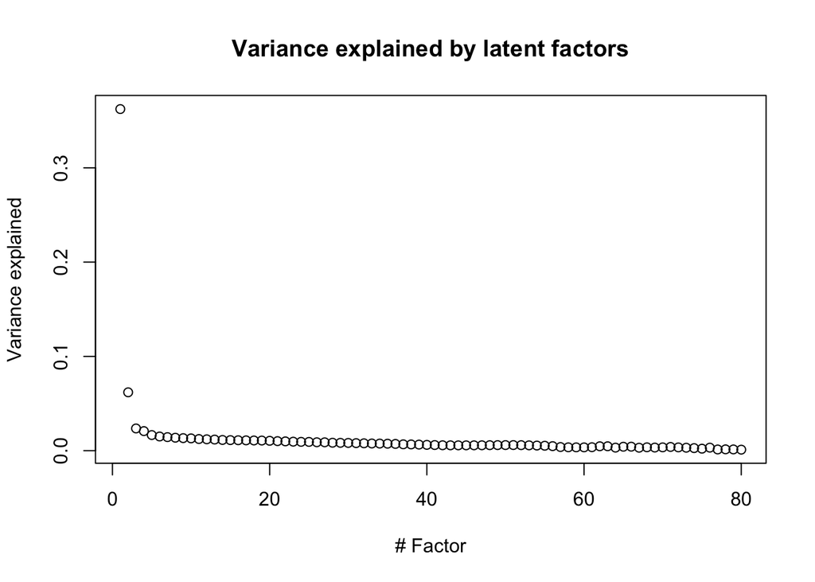

```r
plot(seq(1, length(gplvm_ard$X_ard)), gplvm_ard$X_ard, xlab = '# Factor', ylab = 'Variance explained')
title('Variance explained by latent factors')
```

In this example (and generally when considering cell cycle as the confounding factor), there is a large gap in the proportion of explained variance between the first and the second factor. This suggests, that a single latent factor underlies the variation captured by the cellcycle genes. Consequently, we choose to re-fit the scLVM mdoel with one latent factor only.

```r
gplvm = fitGPLVM(idx=idx_cell_cycle_noise_filtered,k=1,out_dir=out_dir,file_name=file_name,recalc=TRUE, use_ard=FALSE)
```

Next, we plot the inferred cell-cell covarince matirx.

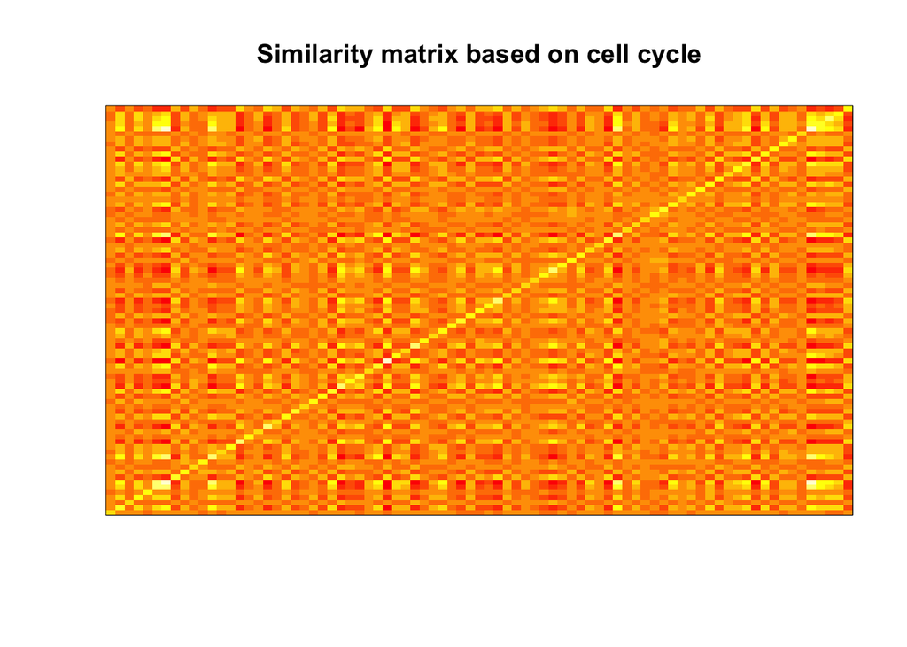

```r
#Plot inferred similarity matrix
Kcc = gplvm_ard$Kcc
image(Kcc,xaxt = "n", yaxt = "n", col = )
title('Similarity matrix based on cell cycle')
```

We first perfrom a variance decomposition on the variable genes.

```r
# considers only heterogeneous genes
Ihet = which(genes_het_bool==1)
Y    = Y[,Ihet]
tech_noise = tech_noise[Ihet]
geneID = geneID[Ihet]
```

The computation time for the next step can be substantial. If large datasets are considerd, it may be advisable to distribute these calculations on a high performance compute cluster. In this case i0 and i1 determine the range of genes for wich this anlaysis is performed. Here, we fit the model on 100 genes.

```r
i0 = 1    # gene from which the analysis starts
i1 = 100   # gene at which the analysis ends

# define sclvm
init_scLVM(Y,geneID=geneID,tech_noise=tech_noise)

# fit the model from i0 to i1
varianceDecomposition(K=Kcc,i0=i0,i1=i1)
```

Once the contribution of cell cycle to the observed variance is estimated, cell-cycled corrected gene expression levels can be obtained. Variance components are normalised such that they sum uo to 1 and genes for which the variance decompostion has not convered are filtered out.

```r
normalize = TRUE    # variance components are normalizaed to sum up to one

# get variance components
results_var = getVarianceComponents(normalize=normalize)
var_filtered = results_var$var[results_var$conv,] # filter out genes for which vd has not converged
head(var_filtered)
```

```
##                     hidden_0 biol_noise tech_noise
## ENSMUSG00000000001 4.127e-01  1.300e-22     0.5873
## ENSMUSG00000000028 1.859e-01  2.650e-21     0.8141
## ENSMUSG00000000056 2.096e-02  2.877e-25     0.9790
## ENSMUSG00000000078 3.343e-01  1.183e-21     0.6657
## ENSMUSG00000000085 6.738e-23  1.869e-21     1.0000
## ENSMUSG00000000131 1.435e-01  9.237e-28     0.8565
```

```r
# get corrected expression levels
Ycorr = getCorrectedExpression()
dim(Ycorr)
```

```
## [1]  81 100
```

After having perfromed the variance decompostion we can illustrate the contributions of the indiviudal components.

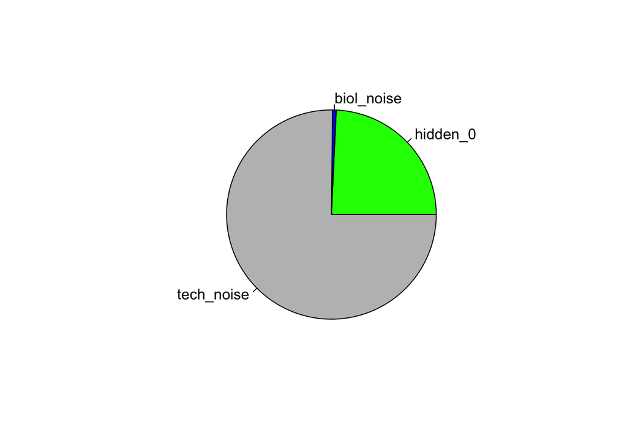

```r
var_mean = apply(var_filtered,2,mean)
colors = c('Green','Blue','Gray')
pie(var_mean, , col = colors)
```

In order to estimate pairwise correlation coefficients whilst controlling for hidden factors such as the cell cycle, we fit a linear mixed model with a fixed effect representing the contribution of another gene j and random effects representing the contribution of the cell cycle and biological variation. Again, as computaion times can be very long we allow the computations to be split up over several calculations for subsets of genes.

```r
i0 = 1     # gene from which the analysis starts
i1 = 5    # gene at which the analysis ends

# fit lmm without correction
res_nocorr = fitLMM(K=NULL,i0=i0,i1=i1,verbose=TRUE, geneID = geneID)

# fit lmm with correction
res_corr = fitLMM(K=Kcc,i0=i0,i1=i1,verbose=TRUE, geneID = geneID)
```

Finally we can have a quick look at the difference between corrected and uncorrected correlations.

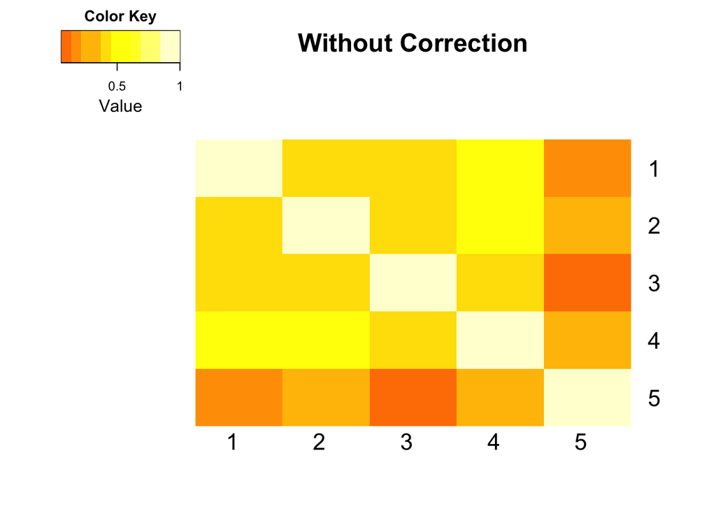

```r
heatmap.2(res_nocorr$beta[,i0:i1], Rowv = NULL, Colv = NULL, dendrogram = "none",
          labCol = as.character(seq(i0:i1)), labRow = as.character(seq(i0:i1)),srtCol = 0, key=T,density.info = "none",
          trace="none", breaks=seq.int(from = -0.6, to = 1.0, length.out = 13), main = 'Without Correction')
```

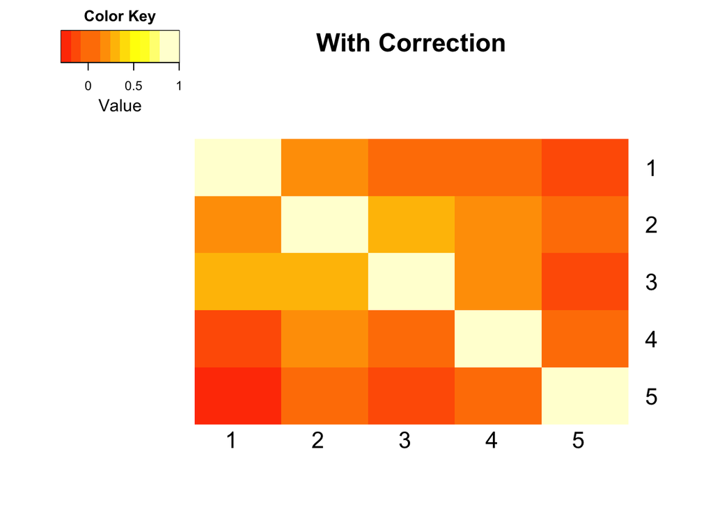

```r
heatmap.2(res_corr$beta[,i0:i1], Rowv = NULL, Colv = NULL, dendrogram = "none",
          labCol = as.character(seq(i0:i1)), labRow = as.character(seq(i0:i1)),srtCol = 0, key=T,density.info = "none",
          trace="none", breaks=seq.int(from = -0.6, to = 1.0, length.out = 13), main = 'With Correction')
```